考虑转化率的构成，就是为了给业务找到业务不好的原因。

> You've been doing a lot of repetitive calculations. Anytime you notice repetition in your work, consider automation.

自动化代码 (repetition automation ) 也就是提高效率的思想 (mindset)。查找这些术语，可以找到一些比较好的资料进行学习。

> The more of the low-variance work you can automate, the more time you will have to explore new and exciting data science topics at work. Since you know the format of the `marketing` DataFrame will remain the same over time, you can build a function to enable you to calculate conversion rate across any sub-segment you want on the fly.

一般来说，自动化主要针对的代码是变动较少的代码，但是需要重复进行，类似于数据中的常数量。

这个转化率的函数设置的非常好，Python 很多函数需要自定义，但是一旦自定义后，都会让工作有效率进行。

```python
import pandas as pd
import matplotlib.pyplot as plt
```

`plot`[[source]](https://github.com/fastai/conversion_metrics/tree/master/conversion_metrics/plot.py#L23)

> `plot`(**`dataframe`**, **`x_rotation_degree`**=*`45`*, **`x_label_size`**=*`12`*)

> You've done the hard work of building your conversion rate function—now it's time to test it out! Automating your analyses can be **time-consuming upfront**, but this is where it all pays off.

upfront 这个词用的挺好。这是一个长期回报的过程。

> By automating the repetitive parts of your work, you'll be able to spend more time doing complex analyses.

节省的时间可以做其他更复杂的分析。

```python
marketing = pd.read_csv("data/marketing.csv")
```

```python
from conversion_metrics import conversion_rate
```

```python
age_group_conv = conversion_rate(marketing, ['date_served', 'age_group'])

# Unstack age_group_conv and create a DataFrame
age_group_df = pd.DataFrame(age_group_conv.unstack(level=1))
```

```python
age_group_df.head()
# 这是一个宽表，for 循环完成
```

| age_group date_served | 0-18 years | 19-24 years | 24-30 years | 30-36 years | 36-45 years | 45-55 years | 55+ years |
| --- | --- | --- | --- | --- | --- | --- | --- |
| 1/1/18 | 0.155172 | 0.196721 | 0.105263 | 0.040816 | 0.042553 | 0.022222 | 0.086957 |
| 1/10/18 | 0.100000 | 0.216667 | 0.129630 | 0.068182 | 0.088889 | 0.090909 | 0.100000 |
| 1/11/18 | 0.085106 | 0.187500 | 0.173913 | 0.000000 | 0.000000 | 0.055556 | 0.029412 |
| 1/12/18 | 0.071429 | 0.226415 | 0.076923 | 0.075000 | 0.000000 | 0.000000 | 0.045455 |
| 1/13/18 | 0.105263 | 0.130435 | 0.113636 | 0.052632 | 0.100000 | 0.023256 | 0.052632 |

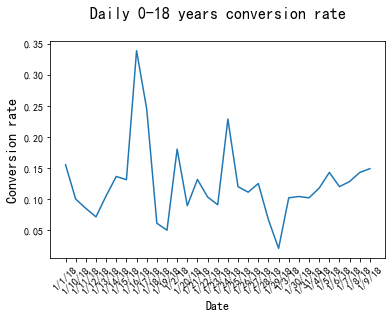

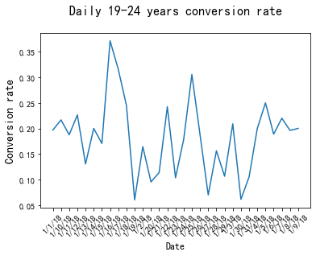

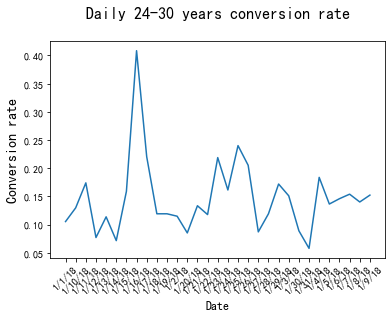

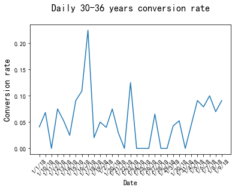

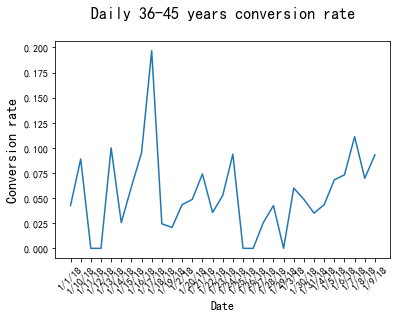

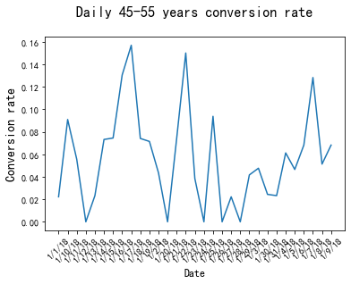

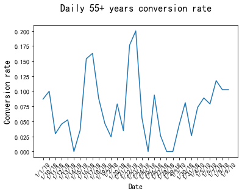

```python
# Plot the results
plot(age_group_df)
```